# DATA612 Project 2

## 8.2 Method Two - using the K-FOld sets

```r
build_IBCF_Model <- function(data, model_to_evaluate, model_parameters ){

                return( Recommender(data = data, method = model_to_evaluate, parameter = model_parameters))
  }
```

```r
data <- getData(eval_sets, "train")
model_to_evaluate <- "IBCF"
model_parameters <- NULL
IBCF_eval_recommender <- build_IBCF_Model(data,model_to_evaluate,model_parameters)
```

```r
IBCF_eval_recommender
```

```
## Recommender of type 'IBCF' for 'realRatingMatrix'
## learned using 308 users.
```

```r
items_to_recommend <- 5
```

```r
IBCF_eval_prediction <- predict(object = IBCF_eval_recommender, newdata = getData(eval_sets, "known"),
                           n = items_to_recommend, type = "ratings")
class(IBCF_eval_prediction)
```

```
## [1] "realRatingMatrix"
## attr(,"package")
## [1] "recommenderlab"
```

```r
number_of_items <- factor(table(IBCF_recc_matrix))
chart_title <- "Distribution of the number of items for IBCF"
```

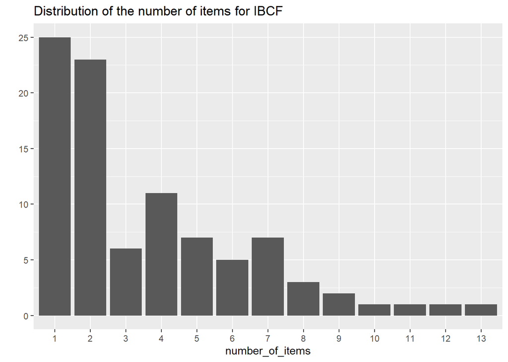

```r
qplot(number_of_items) + ggtitle(chart_title)
```

## 8.3 RMSE

```r
IBCF_eval_accuracy_users <- calcPredictionAccuracy(x = IBCF_eval_prediction, data = getData(eval_sets, "unknown"),
                                        byUser =TRUE)

IBCF_eval_accuracy <- calcPredictionAccuracy(x = IBCF_eval_prediction, data = getData(eval_sets, "unknown"),
                                        byUser =FALSE)
```

```r
head(IBCF_eval_accuracy_users)
```

```
##         RMSE      MSE       MAE
## 7   1.155787 1.335844 0.9632382
## 11  1.202448 1.445880 0.9497916
## 85  1.069236 1.143266 0.8353018
## 95  1.349284 1.820566 0.9992662
## 125 1.693138 2.866715 1.1802906
## 141 1.184097 1.402085 0.8943180
```

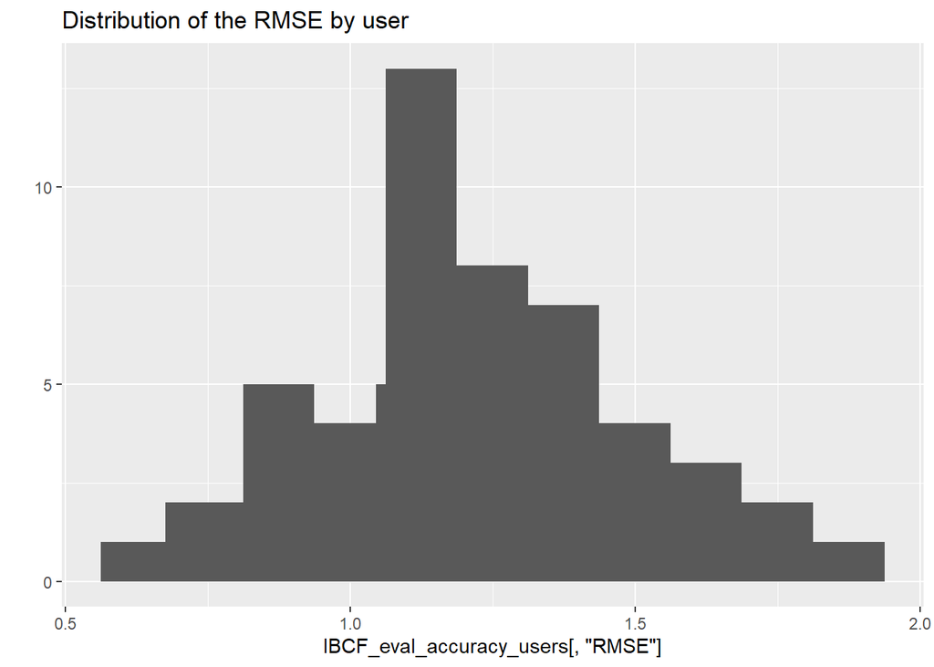

```r
qplot(IBCF_eval_accuracy_users[, "RMSE"]) + geom_histogram(binwidth = 0.125) +
ggtitle("Distribution of the RMSE by user")
```

```r
IBCF_eval_accuracy
```

```
##      RMSE       MSE       MAE
## 1.2377853 1.5321124 0.9417777
```

# 9 Precision and Recall

```r
results <- evaluate(x = eval_sets, method = model_to_evaluate, n =seq(10, 100, 10))
```

```
## IBCF run fold/sample [model time/prediction time]
##   1  [0.03sec/0.02sec]
##   2  [0.03sec/0.02sec]
##   3  [0.03sec/0.02sec]
##   4  [0.03sec/0.02sec]
##   5  [0.03sec/0.02sec]
##   6  [0.03sec/0.02sec]
##   7  [0.05sec/0sec]
##   8  [0.03sec/0sec]
```

```r
head(getConfusionMatrix(results)[[1]])
```

[output not shown]

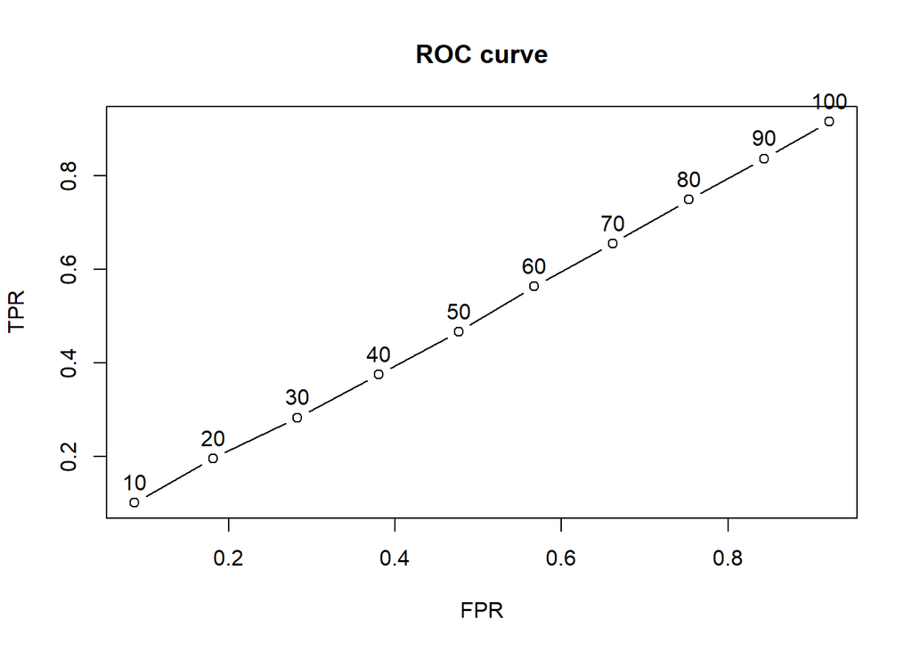

```r
plot(results, annotate = TRUE, main = "ROC curve")
```

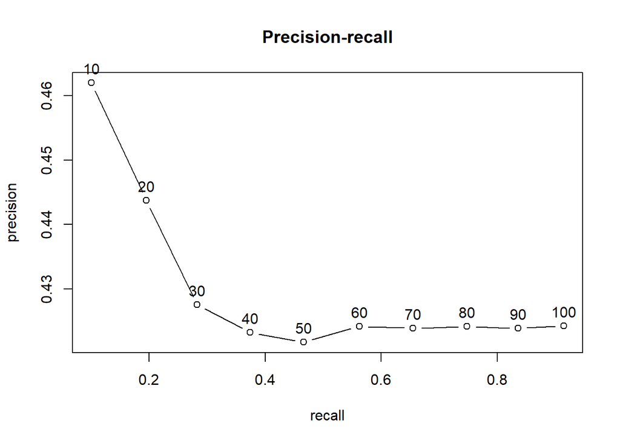

```r
plot(results, "prec/rec", annotate = TRUE, main = "Precision-recall")
```

# 10 Summary

| 7 | 10 | 15 | 21 | 42 |
| --- | --- | --- | --- | --- |
| Titanic (1997) | Princess Bride, The (1987) | Silence of the Lambs, The (1991) | Usual Suspects, The (1995) | Braveheart (1995) |
| Trainspotting (1996) | Boot, Das (1981) | Empire Strikes Back, The (1980) | Shawshank Redemption, The (1994) | Titanic (1997) |
| L.A. Confidential (1997) | To Kill a Mockingbird (1962) | Casablanca (1942) | Schindler’s List (1993) | Conspiracy Theory (1997) |
| Leaving Las Vegas (1995) | Schindler’s List (1993) | Usual Suspects, The (1995) | Clockwork Orange, A (1971) | Contact (1997) |
| Game, The (1997) | Titanic (1997) | Braveheart (1995) | Apocalypse Now (1979) | Air Force One (1997) |

| 7 | 10 | 15 | 21 | 42 |
| --- | --- | --- | --- | --- |
| In & Out (1997) | Godfather: Part II, The (1974) | Groundhog Day (1993) | Graduate, The (1967) | Fish Called Wanda, A (1988) |
| Men in Black (1997) | Truth About Cats & Dogs, The (1996) | Rock, The (1996) | People vs. Larry Flynt, The (1996) | Get Shorty (1995) |
| Leaving Las Vegas (1995) | Star Trek: First Contact (1996) | Scream (1996) | Jerry Maguire (1996) | Murder at 1600 (1997) |
| Ransom (1996) | Birdcage, The (1996) | Leaving Las Vegas (1995) | Sound of Music, The (1965) | Blues Brothers, The (1980) |
| Evita (1996) | Mr. Holland’s Opus (1995) | Stand by Me (1986) | Indiana Jones and the Last Crusade (1989) | English Patient, The (1996) |

## 10.1 Evaluation of models

To evaluate the two models, I created a list of UBCF and IBCF models with different parameters (pearson and cosine). This list was fed into the evaluate function and below. The visualizations below both show that the UBCF using the “pearson” method had the larger area under the curve.

In conclusion, this project has shown that if we want our model to be more precise with its recommendations, we would choose the UBCF model and recommend five or less movies. If the number of recommendations is 50 or above, then the UBCF-pearson model does not perform better than the other models.

```r
models_to_evaluate <- list(IBCF_cos = list(name = "IBCF", param = list(method ="cosine")),
IBCF_cor = list(name = "IBCF", param = list(method ="pearson")),
UBCF_cos = list(name = "UBCF", param = list(method ="cosine")),
UBCF_cor = list(name = "UBCF", param = list(method ="pearson")),
random = list(name = "RANDOM", param=NULL)
)

n_recommendations <- c(1, 5, seq(10, 100, 10))
```

```r
compare_results <- evaluate(x = eval_sets, method = models_to_evaluate, n= n_recommendations)
```

```
## IBCF run fold/sample [model time/prediction time]
##   1  [0.03sec/0.02sec]
##   2  [0.13sec/0.01sec]
##   3  [0.03sec/0sec]
##   4  [0.01sec/0.02sec]
##   5  [0.03sec/0sec]
##   6  [0.01sec/0.02sec]
##   7  [0.02sec/0.01sec]
##   8  [0.04sec/0.02sec]
## IBCF run fold/sample [model time/prediction time]
##   1  [0.03sec/0.02sec]
##   2  [0.05sec/0.18sec]
##   3  [0.03sec/0.02sec]
##   4  [0.04sec/0.02sec]
##   5  [0.07sec/0.01sec]
```

[output cut: 30 more lines]

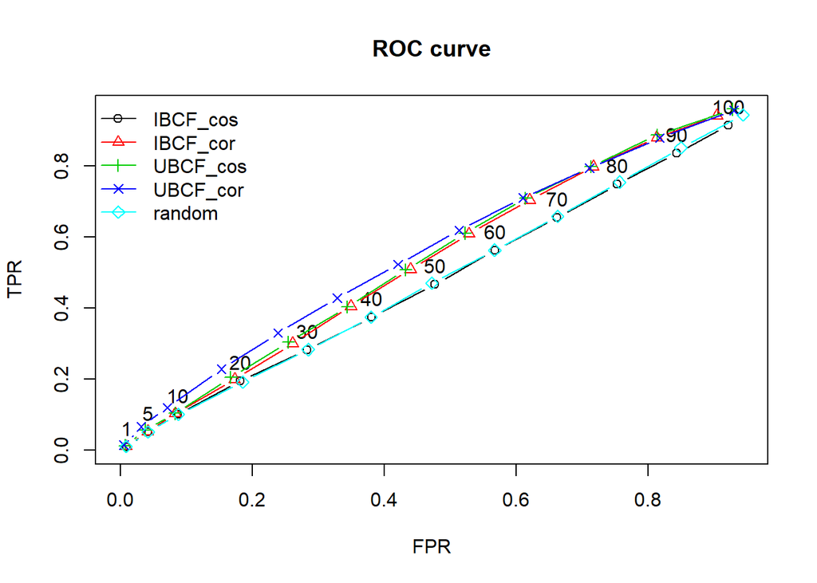

```
## integer(0)
```

```r
plot(compare_results, annotate = 1, legend = "topleft") + title("ROC curve")
```

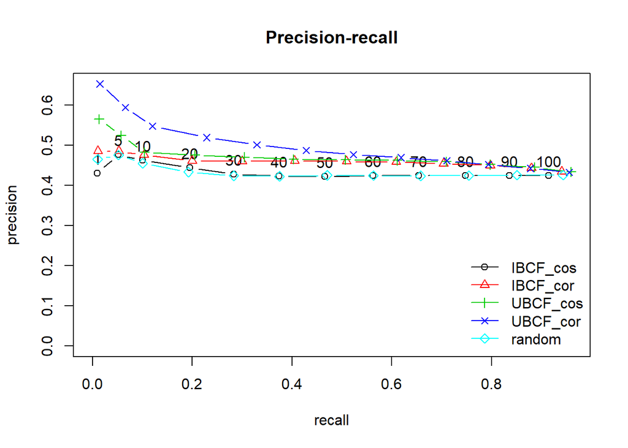

```r
plot(compare_results, "prec/rec", annotate = 1, legend = "bottomright")
title("Precision-recall")
```